# Counting points in multipolygon shapefiles for chloropleth mapping

Summaries

Maps

Eukaryota

Animalia

Choropleth maps are an excellent way to visualise numbers of observations in each region. When using point data, calculating the number of points in each polygon can be difficult when using shapefiles. Here we demonstrate how to extract and summarise the number of points in each polygon within a shapefile to create a choropleth map.

Olivia Torresan , Dax Kellie  
2022-11-21

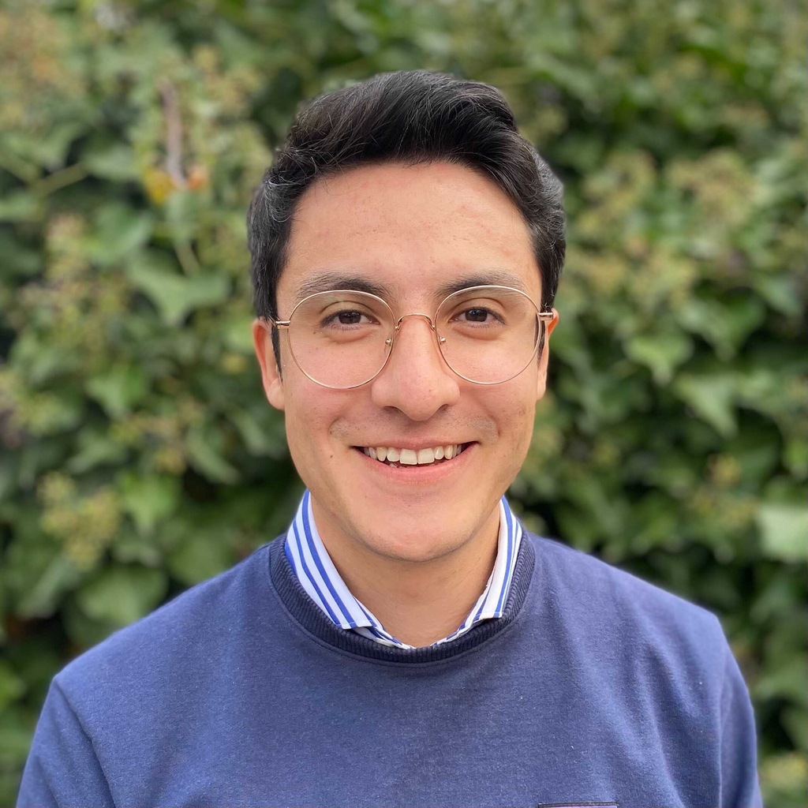

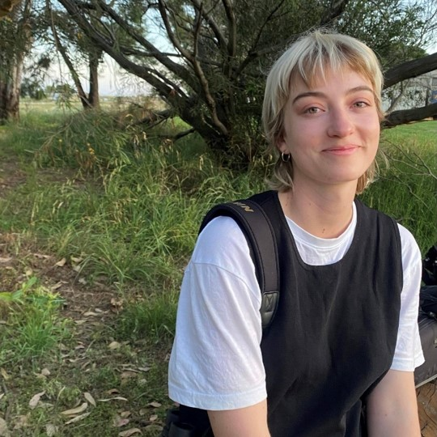

#### Author:

[Olivia Torresan](https://labs.ala.org.au/people/Torresan_Olivia/index.html) [Dax Kellie](https://labs.ala.org.au/people/Kellie_Dax/index.html)

#### Date:

Choropleth maps are an excellent way to visualise differences in variables (eg. number of species observed) across several geographic regions (eg. countries, states, study areas). Often, creating a choropleth map requires that you find and download a shapefile, or a file with vector data of a specific geographic location with detailed information of its geographic features.

Species observations are recorded as point data - the specific longitude and latitude coordinates of where an individual was observed. However, creating a choropleth map that summarises our species observations will require us to summarise our points to a single statistic for each polygon of a shapefile. This conversion from points to polygons can sometimes be tricky.

Here, we show you how to extract and count the number of points inside each polygon of a shapefile to create a choropleth map of the total number of species observations in each suburb of the Australian Capital Territory (ACT).

## Download data

First we will load the R packages that we need:

```r
library(feathers)
library(galah)
library(here)
library(rmapshaper)
library(tidyverse)
library(sf)
```

### Download shapefile

Next we will need a shapefile. You can find many shapefiles online from reputable sources. For this example, I’ve retrieved a shapefile of suburb boundaries in the city of Canberra, ACT from an [open-access state government source](https://www.actmapi.act.gov.au/download.html).

Usually when you download a shapefile, it is compressed within a zip folder. Save this downloaded zip folder in a local folder inside your current [R project](https://r4ds.had.co.nz/workflow-projects.html). If you need to unzip your folder, you can do so with the following code:

```r
zip_folder <- here("folder", "act_localities-folder.zip")
output_dir <- "name-of-folder-to-save-unzipped-files"
unzip(zip_folder, exdir = output_dir)
```

Now we load this unzipped shapefile into R. To save space, we’ll remove some complexity from our shapefile polygons with `ms_simplify()` from the `{rmapshaper}` package.

The `actsuburbs` shapefile also contains both suburb boundaries and “district” boundaries. Districts can encompass several suburbs, and so to avoid confusion, we will remove the districts `filter(LOC_CLASS != "District")` as we are only interested in suburbs. We’ll also use `st_make_valid()` to make sure any weird invalid geometries in our shapefile are made valid, and therefore plot correctly.

```r
actsuburbs <- st_read(here("folder-name",
                           "folder-name-2",
                           "shapefilename.shp") |>
                     ms_simplify(keep = 0.1) |>
  st_transform(crs = st_crs("WGS84")) |>
  st_make_valid() |>
  filter(LOC_CLASS != "District")
```

Now to see if our shapefile plots correctly, we can use `geom_sf()` (and it looks like it does!)

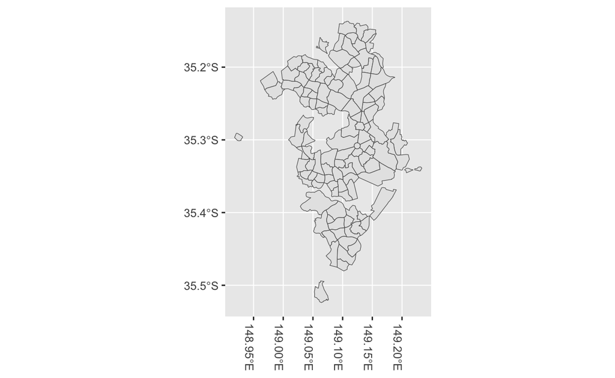

```r
ggplot() +
  geom_sf(data = actsuburbs) +
  theme(axis.text.x=element_text(angle = -90, hjust = 0))
```

### Download species observations

Now let’s use `{galah}` to download bird occurrence records from the [Atlas of Living Australia (ALA)](https://www.ala.org.au/). You will need to provide a [registered email with the ALA](https://auth.ala.org.au/userdetails/registration/createAccount) using `galah_config()` before retrieving records.

```r
galah_config(email = "your-email@email.com", verbose = FALSE)
```

Here, we’ll download all *Aves* (bird) data provided by BirdLife Australia in each suburb. To only download records within the ACT, we can use `galah_filter()` to narrow our download. `galah_apply_profile(ALA)` is also used - a default filter created by the ALA to improve the quality of data retrieved by filtering suspicious records.

```r
birdocc <- galah_call() |>
  galah_identify("Aves") |>
  galah_apply_profile(ALA) |>
  galah_filter(stateProvince == "Australian Capital Territory",
               dataProviderName == "BirdLife Australia") |>
atlas_occurrences()
```

Our records are restricted to the Australian Capital Territory - located here:

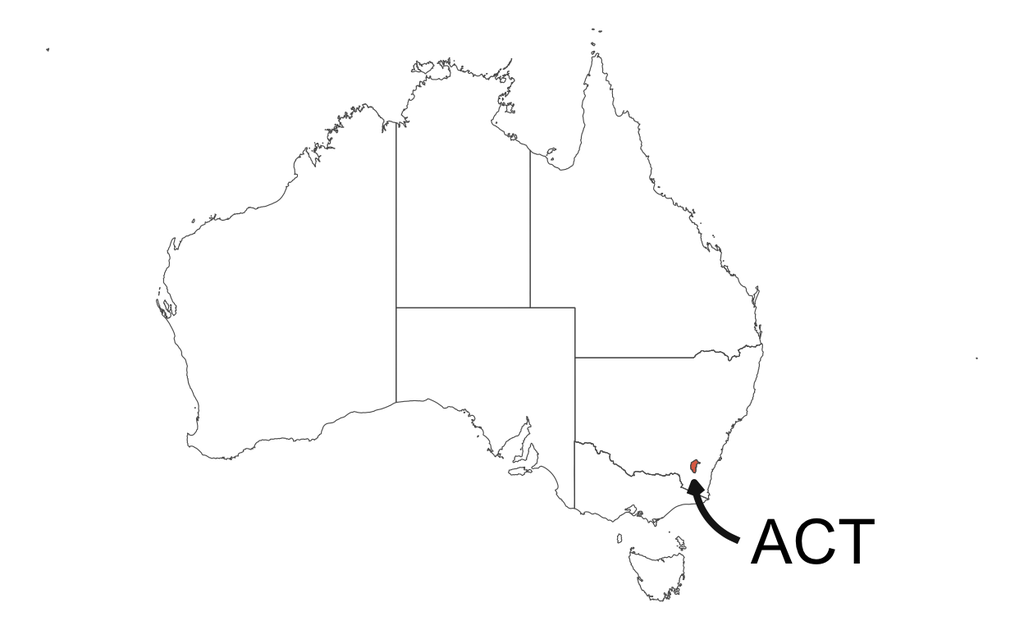

## Prepare data to merge with shapefile

To prepare our data, we’ll convert each observation into a format suitable for spatial mapping. `st_as_sf` is used to transform each point into a `sf` spatial object. We also ensure their projection is consistent with our shapefile with `crs = set_crs("WGS84")` so that the points line up correctly.

```r
birdsfpoints <- birdocc |>
  st_as_sf(coords = c("decimalLongitude", "decimalLatitude"),
  crs = st_crs("WGS84"))
```

Now we’ll find which points are in each of our suburbs using `st_intersects()`. This function checks whether each point is within, or “intersects”, a specified `POLYGON` and then marks it as `TRUE` or `FALSE` in a matrix. In our case, we’ll mark the points that intersect with each suburb.

```r
act_counts <- actsuburbs |>
  mutate(bird_count = pmap(.l = list(x = actsuburbs$geometry),
                           .f = function(x) {
                             lengths(st_intersects(x, birdsfpoints))
                             }))
```

In the spirit of {galah}, we created a galah palette inspired by the [`{feathers}` package](https://github.com/shandiya/feathers): a package of colour palettes from female bird plumages by [Shandiya Balasubramaniam](https://labs.ala.org.au/people/Balasubramaniam_Shandiya/index.html).

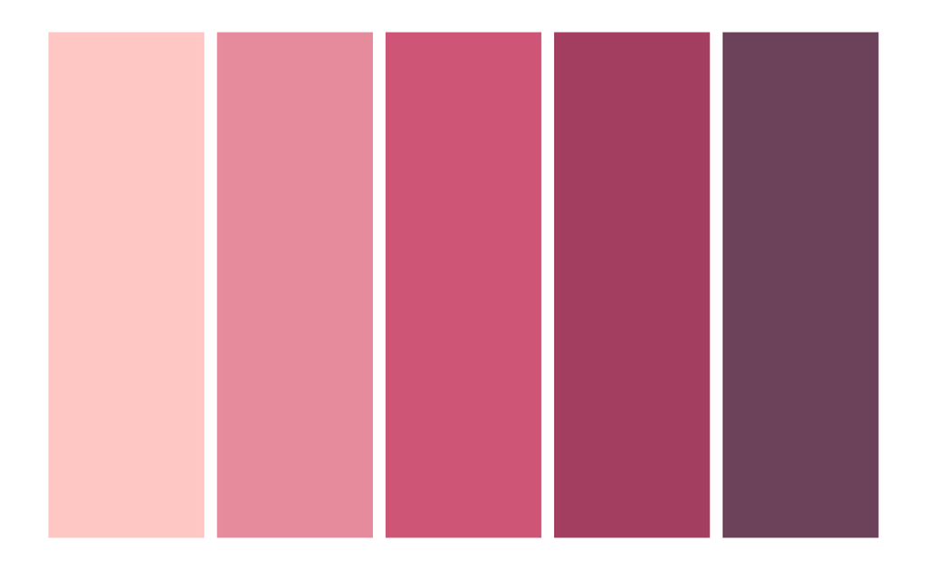

# Map data

Our count data is skewed because many regions have lower numbers of observations and only a few regions have very high numbers of observations. Log transformation will reduce the skew in our data, ultimately making our final choropleth map easier to interpret.

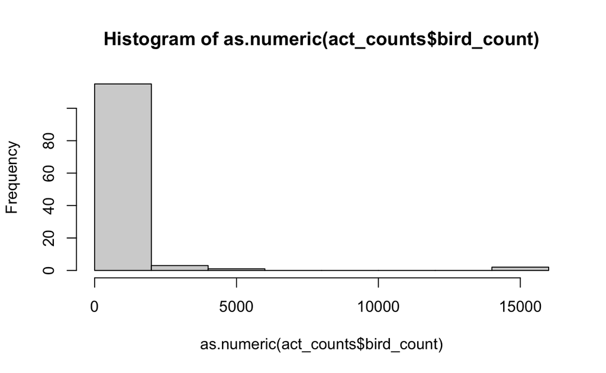

```r
hist(as.numeric(act_counts$bird_count))
```

First, let’s add log-transformed counts to a new `log_counts` column. Next we’ll add a column called `counts_discrete` which uses `cut()` to assign a number from 0 to 5 depending on what range each `log_counts` number falls within (0-1, 1-2, 2-3, 3-4 or 4-5). To make this easier to interpret, we have also added labels that correspond to the normal count values (0, 10, 100, 1000, 10000). Finally, we’ll make sure any `NA` values are converted to 0.

```r
act_counts_log <- act_counts |>
  rowwise() |>
  mutate(log_counts = log10(bird_count)) |>
  mutate(counts_discrete = cut(log_counts,
                               breaks = c(0, 1, 2, 3, 4, 5),
                               labels = c(0, 10, 100, 1000, 10000),
                               include.lowest = TRUE)) |>
  replace_na(list(counts_discrete = "0"))

act_counts_log |> head(5L)
```

```
Simple feature collection with 5 features and 9 fields
Geometry type: POLYGON
Dimension:     XY
Bounding box:  xmin: 149.0735 ymin: -35.48032 xmax: 149.1605 ymax: -35.15856
Geodetic CRS:  WGS 84
# A tibble: 5 × 10
# Rowwise:
  LC_PLY_PID      LOC_PID         DT_CREATE  LOC_NAME LOC_CLASS  STATE
  <chr>           <chr>           <date>     <chr>    <chr>      <chr>
1 lcp1ba238e2cb47 loc6f02f098e82d 2022-03-11 Acton    Gazetted … ACT
2 lcpe9d674c6324f loc8af26acb532d 2022-03-11 Ainslie  Gazetted … ACT
3 lcp22119353bf31 locf0cacaa1119e 2022-03-11 Amaroo   Gazetted … ACT
4 lcp56c03203575e locf94248966b6c 2022-03-11 Aranda   Gazetted … ACT
5 lcp7add4fb70b35 loc76cc01c04bd2 2021-06-24 Banks    Gazetted … ACT
# … with 4 more variables: geometry <POLYGON [°]>, bird_count <list>,
#   log_counts <dbl>, counts_discrete <fct>
```

Now we can use `{ggplot2}` to make our choropleth map!

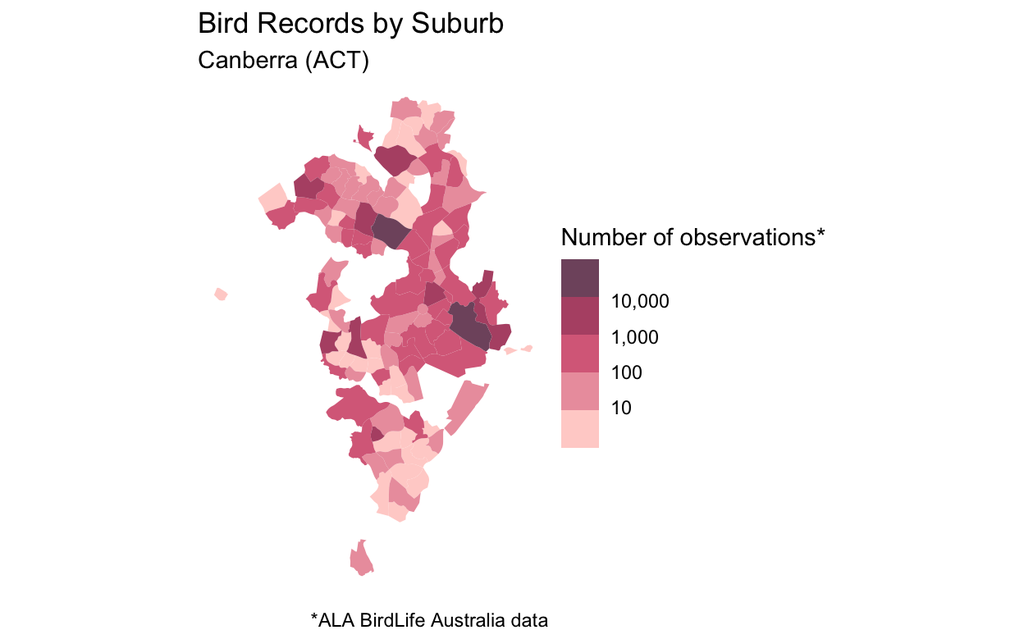

```r
ggplot() +
  geom_sf(
    data = act_counts_log,
    mapping = aes(fill = counts_discrete),
    colour = "NA"
  ) +
  geom_sf() +
  scale_fill_manual(
    name = "Number of observations*",
    drop = FALSE,
    labels = c("10", "100", "1,000", "10,000"),
    values = galah,
    guide = guide_colorsteps(
      direction = "vertical",
      label.position = "right",
      title.position = "top"
    )
  ) +
  labs(
    title = "Bird Records by Suburb",
    subtitle = "Canberra (ACT)",
    caption = "*ALA BirdLife Australia data"
  ) +
  theme_void()
```

# Final thoughts

There’s not much better than a galah-themed choropleth map!

One way you can extend this map is to add floating labels with `geom_text_repel()` or `geom_label_repel()` from the [`{ggrepel}` package](https://ggrepel.slowkow.com/index.html), which we added for our [final version of our map we posted for National Bird Week 2022](https://twitter.com/atlaslivingaust/status/1582495493308829696). Code to add floating labels can be found [here](https://github.com/AtlasOfLivingAustralia/science/blob/main/comms/2022-10-19_backyard-birds-map/backyard%20birds.Rmd).

You can also [learn how to create a choropleth map with two different colour scales in this ALA Labs post](https://labs.ala.org.au/posts/2022-05-23-ggnewscale/)!